# Analise da criminalidade no Estado de São Paulo do ano de 2004

Ricardo Martinelli de Oliveira

April 3, 2018

# 1 Introdução

O objetivo dessa análise é trazer a partir da série histórica de 2004 sobre os dados da criminalidade do Estado de São Paulo. A partir dessa análise será feira ano a ano uma análise detalhada sobre os crimes relatados através dos Boletins de Ocorrência(BO) em posse da Secretaria de Segurança Pública(SSP)[^1] do Estado de São Paulo. Para maiores informações sobre os dados de BOs basta acessar [esse link](http://www.ssp.sp.gov.br/transparenciassp/Consulta.aspx). Iremos também traçar um comparativo do ano de 2003 para avaliar a evolução dos crimes no Estado e avaliar as ações entre os dois anos para verificar a efetividade da Segurança pública.

## 1.1 Nomenclaturas

- **SSP**: Secretaria de Segurança Pública
- **BO**: Boletim de Ocorrência
- **RDO**: Registro Digital de Ocorrências
- **DGP**: Delegacia Geral da Polícia

# 2 Análise

No ano de 2004, a SSP liberou dados de BO dos seguintes tipos de crimes:

- Furto de Veículo
- Homicídio
- Latrocínio
- Lesão Seguida de Morte
- Roubo de Veículo

Somados os dados desses datasets temos 77536 observações, ou seja, o número de BOs registrados durante o ano de 2004 divulgados no site da SSP. Comparado com 2003 que tivemos 45723 BOs, o número cresceu significativamente. O dataset possui no geral as seguintes colunas:

```
##  [1] "X"                        "ANO_BO"
##  [3] "NUM_BO"                   "NUMERO_BOLETIM"
##  [5] "BO_INICIADO"              "BO_EMITIDO"
##  [7] "DATAOCORRENCIA"           "PERIDOOCORRENCIA"
##  [9] "DATACOMUNICACAO"          "DATAELABORACAO"
## [11] "BO_AUTORIA"               "FLAGRANTE"
## [13] "NUMERO_BOLETIM_PRINCIPAL" "LOGRADOURO"
## [15] "NUMERO"                   "BAIRRO"
## [17] "CEP"                      "CIDADE"
## [19] "UF"                       "LATITUDE"
## [21] "LONGITUDE"                "DESCRICAOLOCAL"
## [23] "EXAME"                    "SOLUCAO"
## [25] "DELEGACIA_NOME"           "DELEGACIA_CIRCUNSCRICAO"
## [27] "ESPECIE"                  "RUBRICA"
## [29] "DESDOBRAMENTO"            "STATUS"
## [31] "NOMEPESSOA"               "TIPOPESSOA"
## [33] "VITIMAFATAL"              "RG"
## [35] "RG_UF"                    "NATURALIDADE"
## [37] "NACIONALIDADE"            "SEXO"
## [39] "DATANASCIMENTO"           "IDADE"
## [41] "ESTADOCIVIL"              "PROFISSAO"
## [43] "GRAUINSTRUCAO"            "CORCUTIS"
## [45] "NATUREZAVINCULADA"        "TIPOVINCULO"
## [47] "PLACA_VEICULO"            "UF_VEICULO"
## [49] "CIDADE_VEICULO"           "DESCR_COR_VEICULO"
## [51] "DESCR_MARCA_VEICULO"      "ANO_FABRICACAO"
## [53] "ANO_MODELO"               "DESCR_TIPO_VEICULO"
## [55] "ENDERECOCOMPLETO"         "COORDENADAS"
## [57] "CRIME"
```

Dentre as 57 colunas dos datasets temos dados detalhados sobre cada BO, porém cada crime tem suas particularidades. Ex.: Um BO de furto de veículo não terá dados sobre pessoas uma vez que esses dados são para uso de descrição das vítimas[^2] dos crimes onde houve uma vítima fatal. Outro ponto a ser considerado é a ocasião de aparentemente haver duplicidade de registro de BOs. Isso se deve ao fato de que alguns BOs recebem um complemento (os chamados BOs complementares) que recebem um novo número, e a partir desse número é anexado o número anterior(o chamado BO principal) e compõe o BO como um todo.

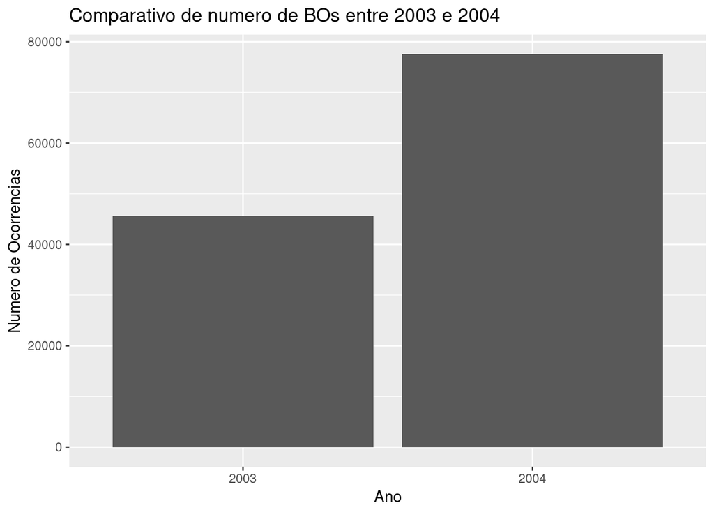

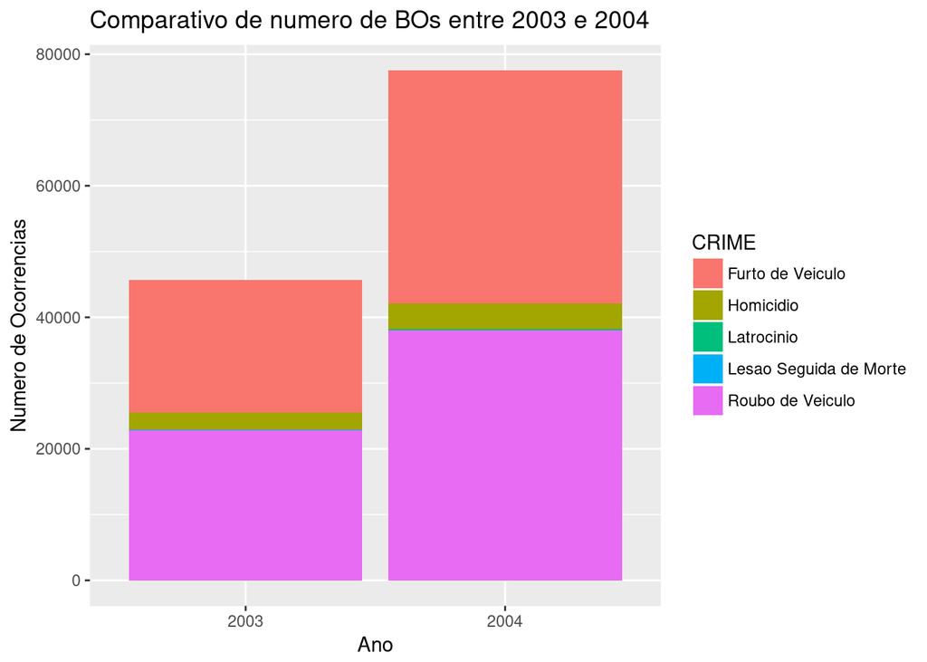

O gráfico abaixo mostra a quantidade de BOs por tipo de crime. Furto e Roubo de Veículo continuam sendo mais relatados que os outros crimes.

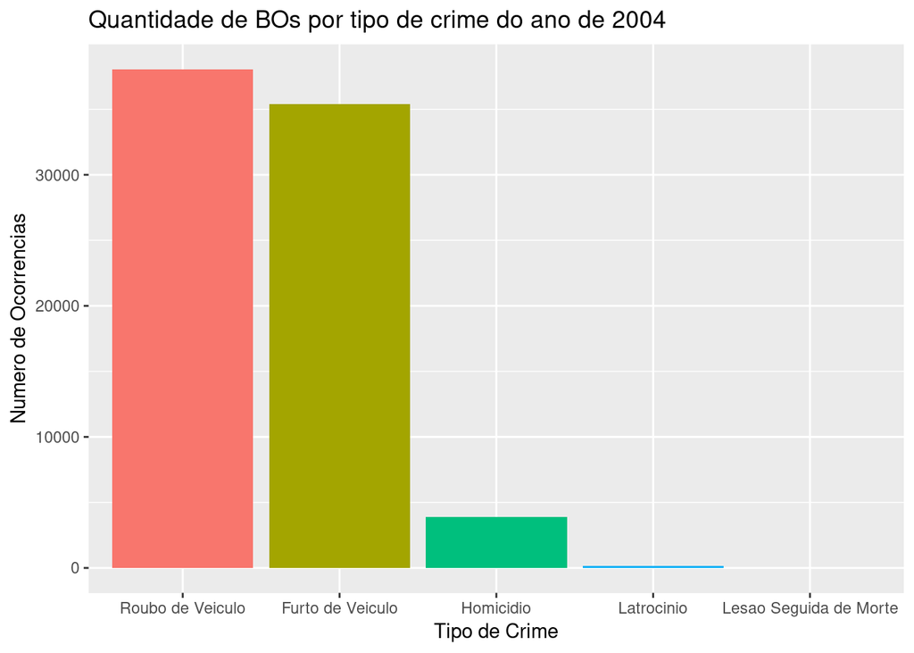

Já o gráfico abaixo mostra o número do ranking das 20 cidades com maiores números de BOs registrados no ano. É importante notar que na ordem das cidades com maior número de ocorrências encontram-se as cidades localizadas na região metropolitana de São Paulo.

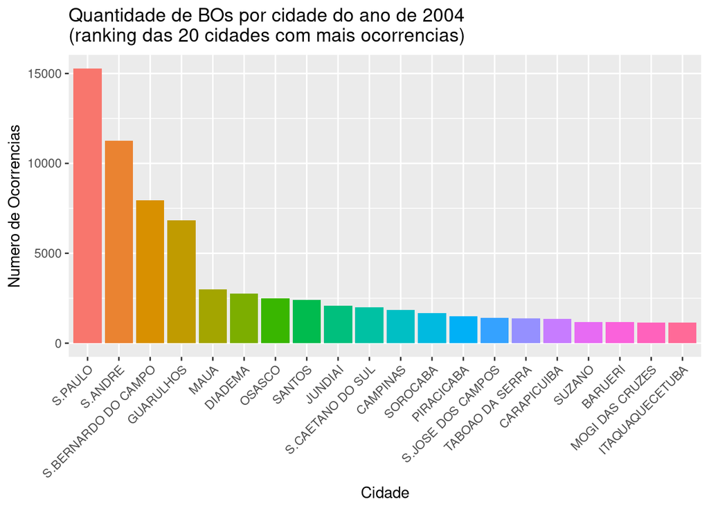

A cidade de São Paulo possuía 5.649.318 de veículos registrados em 2003, de acordo com dados do Detran de SP. Com base nisso, justifica-se o número de ocorrências ser alto na cidade de São Paulo nesse ano. Para maiores detalhes, veremos o gráfico abaixo de número de BOs pelo mesmo ranking das 20 cidades, dessa vez classificando-os por tipo de crime.

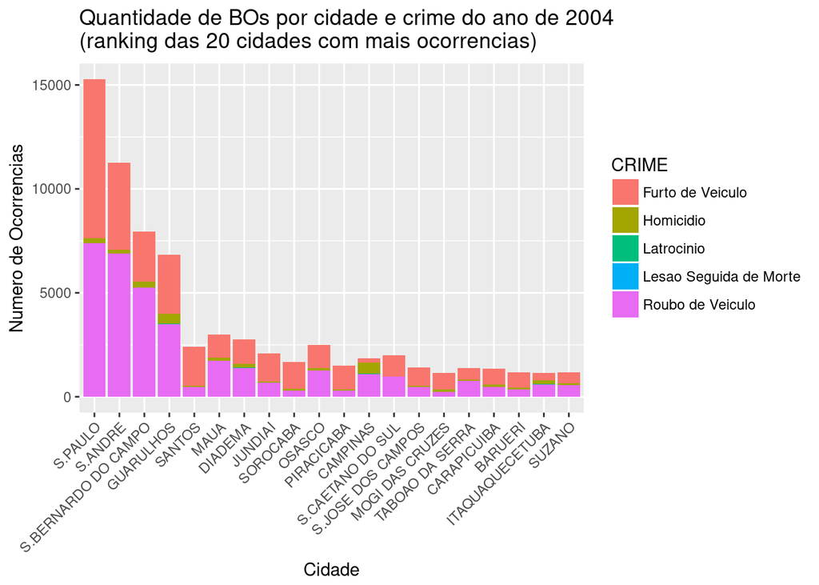

# 3 Problemas

No pouco de análise feita nesse dataset, analisarei nas próximas seções os maiores problemas enfrentados por esses dados.

## 3.1 Crimes com datasets muito pequenos

- **Furto de Veículo**: 35421
- **Homicídio**: 3872
- **Latrocínio**: 177
- **Lesão Seguida de Morte**: 10
- **Roubo de Veículo**: 38056

## 3.2 Muitas variáveis com valores inexistentes

Os dados possuem diversos valores inexistentes, e alguns deles possuem ausência de dados georreferenciados. Isso torna o trabalho complexo para se criar um mapa da criminalidade que possa ser colocado num mapa. Veremos os dados de números inexistentes para cada crime:

- **Furto de Veículo**

```
##                        X                   ANO_BO                   NUM_BO
##                        0                        0                        0
##           NUMERO_BOLETIM              BO_INICIADO               BO_EMITIDO
##                        0                        0                        0
##           DATAOCORRENCIA         PERIDOOCORRENCIA          DATACOMUNICACAO
##                        0                        0                        0
##           DATAELABORACAO               BO_AUTORIA                FLAGRANTE
##                        0                        0                        0
## NUMERO_BOLETIM_PRINCIPAL               LOGRADOURO                   NUMERO
##                        0                        0                        0
##                   BAIRRO                      CEP                   CIDADE
##                        0                    33797                        0
##                       UF                 LATITUDE                LONGITUDE
##                        0                    35421                    35421
##           DESCRICAOLOCAL                    EXAME                  SOLUCAO
##                        0                        0                        0
##           DELEGACIA_NOME  DELEGACIA_CIRCUNSCRICAO                  ESPECIE
##                        0                        0                        0
##                  RUBRICA            DESDOBRAMENTO                   STATUS
##                        0                        0                        0
##               NOMEPESSOA               TIPOPESSOA              VITIMAFATAL
##                    35421                    35421                    35421
##                       RG                    RG_UF             NATURALIDADE
##                    35421                    35421                    35421
##            NACIONALIDADE                     SEXO           DATANASCIMENTO
##                    35421                    35421                    35421
##                    IDADE              ESTADOCIVIL                PROFISSAO
##                    35421                    35421                    35421
##            GRAUINSTRUCAO                 CORCUTIS        NATUREZAVINCULADA
##                    35421                    35421                    35421
##              TIPOVINCULO            PLACA_VEICULO               UF_VEICULO
##                    35421                    35421                    35421
##           CIDADE_VEICULO        DESCR_COR_VEICULO      DESCR_MARCA_VEICULO
##                    35421                    35421                    35421
##           ANO_FABRICACAO               ANO_MODELO       DESCR_TIPO_VEICULO
##                    32384                    32384                    35421
##         ENDERECOCOMPLETO              COORDENADAS                    CRIME
##                        0                        0                        0
```

- **Homicídio**

```
##                        X                   ANO_BO                   NUM_BO
##                        0                        0                        0
##           NUMERO_BOLETIM              BO_INICIADO               BO_EMITIDO
##                        0                        0                        0
##           DATAOCORRENCIA         PERIDOOCORRENCIA          DATACOMUNICACAO
##                        0                        0                        0
##           DATAELABORACAO               BO_AUTORIA                FLAGRANTE
##                        0                        0                        0
## NUMERO_BOLETIM_PRINCIPAL               LOGRADOURO                   NUMERO
##                        0                        0                        0
##                   BAIRRO                      CEP                   CIDADE
##                        0                     3688                        0
##                       UF                 LATITUDE                LONGITUDE
##                        0                     3872                     3872
##           DESCRICAOLOCAL                    EXAME                  SOLUCAO
##                        0                        0                        0
##           DELEGACIA_NOME  DELEGACIA_CIRCUNSCRICAO                  ESPECIE
##                        0                        0                        0
##                  RUBRICA            DESDOBRAMENTO                   STATUS
##                        0                        0                        0
##               NOMEPESSOA               TIPOPESSOA              VITIMAFATAL
##                     3569                     3569                     3569
##                       RG                    RG_UF             NATURALIDADE
##                     3872                     3872                     3569
##            NACIONALIDADE                     SEXO           DATANASCIMENTO
##                     3569                     3569                     3569
##                    IDADE              ESTADOCIVIL                PROFISSAO
##                     3871                     3569                     3872
##            GRAUINSTRUCAO                 CORCUTIS        NATUREZAVINCULADA
##                     3872                     3872                     3569
##              TIPOVINCULO            PLACA_VEICULO               UF_VEICULO
##                     3569                     3872                     3872
##           CIDADE_VEICULO        DESCR_COR_VEICULO      DESCR_MARCA_VEICULO
##                     3872                     3872                     3872
##           ANO_FABRICACAO               ANO_MODELO       DESCR_TIPO_VEICULO
##                        0                        0                     3872
##         ENDERECOCOMPLETO              COORDENADAS                    CRIME
##                        0                        0                        0
```

- **Latrocínio**

```
##                        X                   ANO_BO                   NUM_BO
##                        0                        0                        0
##           NUMERO_BOLETIM              BO_INICIADO               BO_EMITIDO
##                        0                        0                        0
##           DATAOCORRENCIA         PERIDOOCORRENCIA          DATACOMUNICACAO
##                        0                        0                        0
##           DATAELABORACAO               BO_AUTORIA                FLAGRANTE
##                        0                        0                        0
## NUMERO_BOLETIM_PRINCIPAL               LOGRADOURO                   NUMERO
##                        0                        0                        0
##                   BAIRRO                      CEP                   CIDADE
##                        0                      169                        0
##                       UF                 LATITUDE                LONGITUDE
##                        0                      177                      177
##           DESCRICAOLOCAL                    EXAME                  SOLUCAO
##                        0                        0                        0
##           DELEGACIA_NOME  DELEGACIA_CIRCUNSCRICAO                  ESPECIE
##                        0                        0                        0
##                  RUBRICA            DESDOBRAMENTO                   STATUS
##                        0                        0                        0
##               NOMEPESSOA               TIPOPESSOA              VITIMAFATAL
##                      177                      177                      177
##                       RG                    RG_UF             NATURALIDADE
##                      177                      177                      177
##            NACIONALIDADE                     SEXO           DATANASCIMENTO
##                      177                      177                      177
##                    IDADE              ESTADOCIVIL                PROFISSAO
##                      177                      177                      177
##            GRAUINSTRUCAO                 CORCUTIS        NATUREZAVINCULADA
##                      177                      177                      177
##              TIPOVINCULO            PLACA_VEICULO               UF_VEICULO
##                      177                      177                      177
##           CIDADE_VEICULO        DESCR_COR_VEICULO      DESCR_MARCA_VEICULO
##                      177                      177                      177
##           ANO_FABRICACAO               ANO_MODELO       DESCR_TIPO_VEICULO
##                       35                       35                      177
##         ENDERECOCOMPLETO              COORDENADAS                    CRIME
##                        0                        0                        0
```

- **Lesão Seguida de Morte**

```
##                        X                   ANO_BO                   NUM_BO
##                        0                        0                        0
##           NUMERO_BOLETIM              BO_INICIADO               BO_EMITIDO
##                        0                        0                        0
##           DATAOCORRENCIA         PERIDOOCORRENCIA          DATACOMUNICACAO
##                        0                        0                        0
##           DATAELABORACAO               BO_AUTORIA                FLAGRANTE
##                        0                        0                        0
## NUMERO_BOLETIM_PRINCIPAL               LOGRADOURO                   NUMERO
##                        7                        0                        0
##                   BAIRRO                      CEP                   CIDADE
##                        0                        8                        0
##                       UF                 LATITUDE                LONGITUDE
##                        0                       10                       10
##           DESCRICAOLOCAL                    EXAME                  SOLUCAO
##                        0                        1                        0
##           DELEGACIA_NOME  DELEGACIA_CIRCUNSCRICAO                  ESPECIE
##                        0                        0                        0
##                  RUBRICA            DESDOBRAMENTO                   STATUS
##                        0                       10                        0
##               NOMEPESSOA               TIPOPESSOA              VITIMAFATAL
##                       10                       10                       10
##                       RG                    RG_UF             NATURALIDADE
##                       10                       10                       10
##            NACIONALIDADE                     SEXO           DATANASCIMENTO
##                       10                       10                       10
##                    IDADE              ESTADOCIVIL                PROFISSAO
##                       10                       10                       10
##            GRAUINSTRUCAO                 CORCUTIS        NATUREZAVINCULADA
##                       10                       10                       10
##              TIPOVINCULO            PLACA_VEICULO               UF_VEICULO
##                       10                       10                       10
##           CIDADE_VEICULO        DESCR_COR_VEICULO      DESCR_MARCA_VEICULO
##                       10                       10                       10
##           ANO_FABRICACAO               ANO_MODELO       DESCR_TIPO_VEICULO
##                        0                        0                       10
##         ENDERECOCOMPLETO              COORDENADAS                    CRIME
##                        0                        0                        0
```

- **Roubo de Veículo**

```
##                        X                   ANO_BO                   NUM_BO
##                        0                        0                        0
##           NUMERO_BOLETIM              BO_INICIADO               BO_EMITIDO
##                        0                        0                        0
##           DATAOCORRENCIA         PERIDOOCORRENCIA          DATACOMUNICACAO
##                        0                        0                        0
##           DATAELABORACAO               BO_AUTORIA                FLAGRANTE
##                        0                        0                        0
## NUMERO_BOLETIM_PRINCIPAL               LOGRADOURO                   NUMERO
##                        0                        0                        0
##                   BAIRRO                      CEP                   CIDADE
##                        0                    36797                        0
##                       UF                 LATITUDE                LONGITUDE
##                        0                    38056                    38056
##           DESCRICAOLOCAL                    EXAME                  SOLUCAO
##                        0                        0                        0
##           DELEGACIA_NOME  DELEGACIA_CIRCUNSCRICAO                  ESPECIE
##                        0                        0                        0
##                  RUBRICA            DESDOBRAMENTO                   STATUS
##                        0                        0                        0
##               NOMEPESSOA               TIPOPESSOA              VITIMAFATAL
##                    38056                    38056                    38056
##                       RG                    RG_UF             NATURALIDADE
##                    38056                    38056                    38056
##            NACIONALIDADE                     SEXO           DATANASCIMENTO
##                    38056                    38056                    38056
##                    IDADE              ESTADOCIVIL                PROFISSAO
##                    38056                    38056                    38056
##            GRAUINSTRUCAO                 CORCUTIS        NATUREZAVINCULADA
##                    38056                    38056                    38056
##              TIPOVINCULO            PLACA_VEICULO               UF_VEICULO
##                    38056                    38056                    38056
##           CIDADE_VEICULO        DESCR_COR_VEICULO      DESCR_MARCA_VEICULO
##                    38056                    38056                    38056
##           ANO_FABRICACAO               ANO_MODELO       DESCR_TIPO_VEICULO
##                    23925                    23925                    38056
##         ENDERECOCOMPLETO              COORDENADAS                    CRIME
##                        0                        0                        0
```

Para tanto, o trabalho feito para criar tais dados georreferenciados foi utilizar da API do Google Maps para conseguir trazer esses dados. Como o dataset é pequeno, pode-se coletar esses dados pela API, mas pelo fato de a API ter uma limitação para uma busca gratuita isso pode se tornar uma limitação e com isso seja necessário pagar para conseguir trazer esses dados num dataset muito maior. Esse até o momento é a maior limitação do dataset para qualquer análise que possa ser feita, e para os próximos anos procurarei uma forma melhor de conseguir os dados.

# 4 Conclusão

Mesmo no ano de 2004 ainda estamos perdendo muitos dados por conta de dados inexistentes, necessários para fazer o correto georeferenciamento dos crimes no Estado de SP. Para o ano de 2005 o que deve ser feito é ter a certeza de que os dados utilizados para buscar os dados georeferenciados estejam de acordo, de forma que os dados possam ser retornados com sucesso.

Os dados deste dataset ficarão disponibilizados de forma georreferenciada no link [Mapas](https://rimolive.github.io/mapa-crime-sp/).

[^1]: A fonte dos dados de transparência é do Sistema de Registro Digital de ocorrências (RDO) e portanto nem todos os BOs estão nessa análise.
[^2]: Para garantir a privacidade das famílias envolvidas, nomes e outros dados pessoais não serão mencionados.
[^3]: http://www.ssp.sp.gov.br/Estatistica/Pesquisa.aspx